# 5205 Group Project

Group 8

We would like to understand whether covid is a factor makes the unemployment rate fluctuates during 2020 and 2021. First of all, we have to make sure the data is started from 2020, because the case number of covid boosted from 2020 March.

```r
data <- read.csv('final_data.csv')

covid <- data[-c(1:10),]
covid <- covid[-c(3:12),]
covid <- covid[-c(5:14),]
covid <- covid[-c(7:16),]
covid <- covid[-c(9:18),]
covid <- covid[-c(11:20),]
covid <- covid[-c(13:22),]
covid <- covid[-c(15:24),]
covid <- covid[-c(17:26),]
covid <- covid[-c(19:28),]
covid <- covid[-c(21:30),]
covid <- covid[-c(23:32),]
```

Linear regression is used to test the relationship between covid case and unemployment rate. A p value smaller than 0.05 is considered as significant, which indicates a linear relationship between those two factors.

US case and educational level

```r
##Primary_School
model_ps <- lm(Primary_School~US_case, covid)
summary(model_ps)
```

```
Call:
lm(formula = Primary_School ~ US_case, data = covid)

Residuals:
    Min      1Q  Median      3Q     Max
-7.0969 -1.2043  0.0534  0.7885  8.6824

Coefficients:
              Estimate Std. Error t value Pr(>|t|)
(Intercept)  1.260e+01  1.194e+00  10.552  4.5e-10 ***
US_case     -3.998e-09  1.464e-09  -2.731   0.0122 *
---
Signif. codes:  0 ‘***’ 0.001 ‘**’ 0.01 ‘*’ 0.05 ‘.’ 0.1 ‘ ’ 1

Residual standard error: 3.759 on 22 degrees of freedom
Multiple R-squared:  0.2531,    Adjusted R-squared:  0.2192
F-statistic: 7.456 on 1 and 22 DF,  p-value: 0.01221
```

```r
##High_School
model_hs <- lm(High_School~US_case, covid)
summary(model_hs)
```

```
Call:
lm(formula = High_School ~ US_case, data = covid)

Residuals:
    Min      1Q  Median      3Q     Max
-5.9537 -0.2620 -0.0693  0.3293  7.8053

Coefficients:
              Estimate Std. Error t value Pr(>|t|)
(Intercept)  9.554e+00  9.643e-01   9.907 1.43e-09 ***
US_case     -2.975e-09  1.183e-09  -2.515   0.0197 *
---
Signif. codes:  0 ‘***’ 0.001 ‘**’ 0.01 ‘*’ 0.05 ‘.’ 0.1 ‘ ’ 1

Residual standard error: 3.037 on 22 degrees of freedom
Multiple R-squared:  0.2233,    Adjusted R-squared:  0.188
F-statistic: 6.326 on 1 and 22 DF,  p-value: 0.0197
```

```r
##Associates_Degree
model_ad <- lm(Associates_Degree~US_case, covid)
summary(model_ad)
```

```
Call:
lm(formula = Associates_Degree ~ US_case, data = covid)

Residuals:
    Min      1Q  Median      3Q     Max
-5.4564 -0.4794  0.0553  0.4011  6.7998

Coefficients:
              Estimate Std. Error t value Pr(>|t|)
(Intercept)  8.256e+00  8.746e-01    9.44 3.41e-09 ***
US_case     -2.832e-09  1.073e-09   -2.64   0.0149 *
---
Signif. codes:  0 ‘***’ 0.001 ‘**’ 0.01 ‘*’ 0.05 ‘.’ 0.1 ‘ ’ 1

Residual standard error: 2.754 on 22 degrees of freedom
Multiple R-squared:  0.2406,    Adjusted R-squared:  0.2061
F-statistic: 6.971 on 1 and 22 DF,  p-value: 0.01495
```

```r
##Professional_Degree
model_pd <- lm(Professional_Degree~US_case, covid)
summary(model_pd)
```

```
Call:
lm(formula = Professional_Degree ~ US_case, data = covid)

Residuals:
    Min      1Q  Median      3Q     Max
-3.2274 -0.2889 -0.0260  0.2680  3.3098

Coefficients:
              Estimate Std. Error t value Pr(>|t|)
(Intercept)  5.127e+00  4.855e-01  10.562 4.42e-10 ***
US_case     -1.872e-09  5.954e-10  -3.144  0.00472 **
---
Signif. codes:  0 ‘***’ 0.001 ‘**’ 0.01 ‘*’ 0.05 ‘.’ 0.1 ‘ ’ 1

Residual standard error: 1.529 on 22 degrees of freedom
Multiple R-squared:   0.31, Adjusted R-squared:  0.2786
F-statistic: 9.883 on 1 and 22 DF,  p-value: 0.004717
```

US case and race

```r
##White
model_w <- lm(White~US_case, covid)
summary(model_w)
```

```
Call:
lm(formula = White ~ US_case, data = covid)

Residuals:
    Min      1Q  Median      3Q     Max
-4.6815 -0.2467 -0.0308  0.1723  6.4738

Coefficients:
              Estimate Std. Error t value Pr(>|t|)
(Intercept)  7.781e+00  7.842e-01   9.923 1.39e-09 ***
US_case     -2.786e-09  9.619e-10  -2.896  0.00838 **
---
Signif. codes:  0 ‘***’ 0.001 ‘**’ 0.01 ‘*’ 0.05 ‘.’ 0.1 ‘ ’ 1

Residual standard error: 2.47 on 22 degrees of freedom
Multiple R-squared:  0.276, Adjusted R-squared:  0.2431
F-statistic: 8.389 on 1 and 22 DF,  p-value: 0.008376
```

```r
##Black
model_b <- lm(Black~US_case, covid)
summary(model_b)
```

```
Call:
lm(formula = Black ~ US_case, data = covid)

Residuals:
    Min      1Q  Median      3Q     Max
-6.1110 -0.5412  0.1730  0.6455  5.0234

Coefficients:
              Estimate Std. Error t value Pr(>|t|)
(Intercept)  1.191e+01  9.012e-01  13.217 6.08e-12 ***
US_case     -2.967e-09  1.105e-09  -2.684   0.0136 *
---
Signif. codes:  0 ‘***’ 0.001 ‘**’ 0.01 ‘*’ 0.05 ‘.’ 0.1 ‘ ’ 1

Residual standard error: 2.838 on 22 degrees of freedom
Multiple R-squared:  0.2467,    Adjusted R-squared:  0.2124
F-statistic: 7.203 on 1 and 22 DF,  p-value: 0.01356
```

```r
##Asian
model_a <- lm(Asian~US_case, covid)
summary(model_a)
```

```
Call:
lm(formula = Asian ~ US_case, data = covid)

Residuals:
    Min      1Q  Median      3Q     Max
-6.7154 -0.8141  0.0704  0.4383  5.9534

Coefficients:
              Estimate Std. Error t value Pr(>|t|)
(Intercept)  9.215e+00  1.000e+00   9.216 5.22e-09 ***
US_case     -3.728e-09  1.227e-09  -3.039  0.00602 **
---
Signif. codes:  0 ‘***’ 0.001 ‘**’ 0.01 ‘*’ 0.05 ‘.’ 0.1 ‘ ’ 1

Residual standard error: 3.149 on 22 degrees of freedom
Multiple R-squared:  0.2957,    Adjusted R-squared:  0.2637
F-statistic: 9.236 on 1 and 22 DF,  p-value: 0.006022
```

```r
##Hispanic
model_h <- lm(Hispanic~US_case, covid)
summary(model_h)
```

```
Call:
lm(formula = Hispanic ~ US_case, data = covid)

Residuals:
    Min      1Q  Median      3Q     Max
-6.7594 -0.4608  0.0862  0.3301  7.9156

Coefficients:
              Estimate Std. Error t value Pr(>|t|)
(Intercept)  1.106e+01  1.064e+00  10.398 5.91e-10 ***
US_case     -3.778e-09  1.305e-09  -2.896  0.00838 **
---
Signif. codes:  0 ‘***’ 0.001 ‘**’ 0.01 ‘*’ 0.05 ‘.’ 0.1 ‘ ’ 1

Residual standard error: 3.349 on 22 degrees of freedom
Multiple R-squared:  0.276, Adjusted R-squared:  0.2431
F-statistic: 8.386 on 1 and 22 DF,  p-value: 0.008384
```

US case and gender

```r
##Men
model_men <- lm(Men~US_case, covid)
summary(model_men)
```

```
Call:
lm(formula = Men ~ US_case, data = covid)

Residuals:
    Min      1Q  Median      3Q     Max
-4.5639 -0.3798 -0.0029  0.4943  5.1836

Coefficients:
              Estimate Std. Error t value Pr(>|t|)
(Intercept)  7.864e+00  7.091e-01  11.090 1.78e-10 ***
US_case     -2.398e-09  8.697e-10  -2.757   0.0115 *
---
Signif. codes:  0 ‘***’ 0.001 ‘**’ 0.01 ‘*’ 0.05 ‘.’ 0.1 ‘ ’ 1

Residual standard error: 2.233 on 22 degrees of freedom
Multiple R-squared:  0.2567,    Adjusted R-squared:  0.2229
F-statistic: 7.599 on 1 and 22 DF,  p-value: 0.01151
```

```r
##Women
model_women <- lm(Women~US_case, covid)
summary(model_women)
```

```
Call:
lm(formula = Women ~ US_case, data = covid)

Residuals:
    Min      1Q  Median      3Q     Max
-5.3883 -0.3934 -0.0388  0.2152  7.0741

Coefficients:
              Estimate Std. Error t value Pr(>|t|)
(Intercept)  8.488e+00  8.985e-01   9.447 3.36e-09 ***
US_case     -3.150e-09  1.102e-09  -2.859  0.00913 **
---
Signif. codes:  0 ‘***’ 0.001 ‘**’ 0.01 ‘*’ 0.05 ‘.’ 0.1 ‘ ’ 1

Residual standard error: 2.829 on 22 degrees of freedom
Multiple R-squared:  0.2709,    Adjusted R-squared:  0.2377
F-statistic: 8.172 on 1 and 22 DF,  p-value: 0.009129
```

All of the p values are less than 0.05. Therefore, we can conclude that covid does influence US unemployment rate of different people.

To make further interpretation, we select the top 4 populous states in the US to test the influence of covid on unemployment rate by linear regression.

```r
##California
model_cal <- lm(California~Cal_case, covid)
summary(model_cal)
```

```
Call:
lm(formula = California ~ Cal_case, data = covid)

Residuals:
    Min      1Q  Median      3Q     Max
-6.6021 -0.5890  0.1042  0.6604  5.4646

Coefficients:
              Estimate Std. Error t value Pr(>|t|)
(Intercept)  1.070e+01  9.623e-01  11.121 1.69e-10 ***
Cal_case    -2.678e-08  1.053e-08  -2.544   0.0185 *
---
Signif. codes:  0 ‘***’ 0.001 ‘**’ 0.01 ‘*’ 0.05 ‘.’ 0.1 ‘ ’ 1

Residual standard error: 3.016 on 22 degrees of freedom
Multiple R-squared:  0.2273,    Adjusted R-squared:  0.1921
F-statistic:  6.47 on 1 and 22 DF,  p-value: 0.01851
```

```r
##Florida
model_flo <- lm(Florida~Flo_case, covid)
summary(model_flo)
```

```
Call:
lm(formula = Florida ~ Flo_case, data = covid)

Residuals:
    Min      1Q  Median      3Q     Max
-5.9546 -0.5089 -0.3333  0.6169  5.3119

Coefficients:
              Estimate Std. Error t value Pr(>|t|)
(Intercept)  8.655e+00  8.702e-01   9.945 1.33e-09 ***
Flo_case    -4.765e-08  1.418e-08  -3.360  0.00283 **
---
Signif. codes:  0 ‘***’ 0.001 ‘**’ 0.01 ‘*’ 0.05 ‘.’ 0.1 ‘ ’ 1

Residual standard error: 2.773 on 22 degrees of freedom
Multiple R-squared:  0.3392,    Adjusted R-squared:  0.3091
F-statistic: 11.29 on 1 and 22 DF,  p-value: 0.002827
```

```r
##Texas
model_tex <- lm(Texas~Tex_case, covid)
summary(model_tex)
```

```
Call:
lm(formula = Texas ~ Tex_case, data = covid)

Residuals:
    Min      1Q  Median      3Q     Max
-4.6232 -0.2180 -0.0219  0.2792  4.5854

Coefficients:
              Estimate Std. Error t value Pr(>|t|)
(Intercept)  8.023e+00  6.548e-01  12.252 2.66e-11 ***
Tex_case    -2.310e-08  8.812e-09  -2.622   0.0156 *
---
Signif. codes:  0 ‘***’ 0.001 ‘**’ 0.01 ‘*’ 0.05 ‘.’ 0.1 ‘ ’ 1

Residual standard error: 2.063 on 22 degrees of freedom
Multiple R-squared:  0.2381,    Adjusted R-squared:  0.2034
F-statistic: 6.874 on 1 and 22 DF,  p-value: 0.01558
```

```r
##New York
model_ny <- lm(NY~NY_case, covid)
summary(model_ny)
```

```
Call:
lm(formula = NY ~ NY_case, data = covid)

Residuals:
    Min      1Q  Median      3Q     Max
-6.3538 -0.5389 -0.0173  0.4662  6.7642

Coefficients:
              Estimate Std. Error t value Pr(>|t|)
(Intercept)  1.025e+01  1.088e+00   9.427 3.49e-09 ***
NY_case     -4.796e-08  2.278e-08  -2.105   0.0469 *
---
Signif. codes:  0 ‘***’ 0.001 ‘**’ 0.01 ‘*’ 0.05 ‘.’ 0.1 ‘ ’ 1

Residual standard error: 3.282 on 22 degrees of freedom
Multiple R-squared:  0.1677,    Adjusted R-squared:  0.1298
F-statistic: 4.432 on 1 and 22 DF,  p-value: 0.04692
```

Similarly, covid does impact on individual state’s unemployment rate, especially Florida.

```r
unemp <- read.csv('final_data.csv')
str(unemp)
```

```
'data.frame':   144 obs. of  21 variables:
 $ Year               : int  2010 2011 2012 2013 2014 2015 2016 2017 2018 2019 ...
 $ Month              : chr  "Jan" "Jan" "Jan" "Jan" ...
 $ Primary_School     : num  15.3 14.3 13 12 9.4 8.3 7.1 7.4 5.4 5.7 ...
 $ High_School        : num  10.2 9.5 8.5 8.1 6.5 5.4 5.2 5.2 4.4 3.7 ...
 $ Associates_Degree  : num  8.6 8.1 7.1 6.9 5.9 5.2 4.2 3.8 3.4 3.4 ...
 $ Professional_Degree: num  4.9 4.3 4.3 3.8 3.3 2.8 2.5 2.5 2.1 2.4 ...
 $ White              : num  8.8 8.1 7.4 7.1 5.7 4.9 4.2 4.2 3.5 3.5 ...
 $ Black              : num  16.5 15.8 13.6 13.7 12.1 10.3 8.7 7.5 7.5 6.8 ...
 $ Asian              : num  8.3 6.8 6.7 6.4 4.7 4 3.6 3.7 3 3.1 ...
 $ Hispanic           : num  12.9 12.3 10.7 9.7 8.3 6.7 5.8 5.8 5 4.8 ...
 $ Men                : num  10.2 9 7.7 7.5 6.2 5.3 4.4 4.3 3.8 3.7 ...
 $ Women              : num  7.9 7.9 7.6 7.2 5.8 5 4.5 4.4 3.6 3.6 ...
 $ California         : num  12.6 12.3 11.2 9.7 8.2 6.8 5.7 5.2 4.4 4.3 ...
 $ Florida            : num  10.9 10.6 9.2 8 6.9 5.9 5.1 4.7 4 3.5 ...
 $ Texas              : num  8.3 8.2 7.1 6.5 5.7 4.6 4.5 4.8 4.1 3.7 ...
 $ NY                 : num  9 8.4 8.6 8.3 7 5.7 4.8 4.7 4.5 3.9 ...
 $ Cal_case           : int  0 0 0 0 0 0 0 0 0 0 ...
 $ Flo_case           : int  0 0 0 0 0 0 0 0 0 0 ...
 $ Tex_case           : int  0 0 0 0 0 0 0 0 0 0 ...
 $ NY_case            : int  0 0 0 0 0 0 0 0 0 0 ...
 $ US_case            : int  0 0 0 0 0 0 0 0 0 0 ...
```

```r
head(unemp,10)
```

|  | Year | Month | Primary_School | High_School | Associates_Degree | Professional_Degree | White | Black | Asian | Hispanic | Men | Women | California | Florida | Texas | NY | Cal_case | Flo_case | Tex_case | NY_case | US_case |
| --- | --- | --- | --- | --- | --- | --- | --- | --- | --- | --- | --- | --- | --- | --- | --- | --- | --- | --- | --- | --- | --- |
| 1 | 2010 | Jan | 15.3 | 10.2 | 8.6 | 4.9 | 8.8 | 16.5 | 8.3 | 12.9 | 10.2 | 7.9 | 12.6 | 10.9 | 8.3 | 9.0 | 0 | 0 | 0 | 0 | 0 |
| 2 | 2011 | Jan | 14.3 | 9.5 | 8.1 | 4.3 | 8.1 | 15.8 | 6.8 | 12.3 | 9.0 | 7.9 | 12.3 | 10.6 | 8.2 | 8.4 | 0 | 0 | 0 | 0 | 0 |
| 3 | 2012 | Jan | 13.0 | 8.5 | 7.1 | 4.3 | 7.4 | 13.6 | 6.7 | 10.7 | 7.7 | 7.6 | 11.2 | 9.2 | 7.1 | 8.6 | 0 | 0 | 0 | 0 | 0 |
| 4 | 2013 | Jan | 12.0 | 8.1 | 6.9 | 3.8 | 7.1 | 13.7 | 6.4 | 9.7 | 7.5 | 7.2 | 9.7 | 8.0 | 6.5 | 8.3 | 0 | 0 | 0 | 0 | 0 |
| 5 | 2014 | Jan | 9.4 | 6.5 | 5.9 | 3.3 | 5.7 | 12.1 | 4.7 | 8.3 | 6.2 | 5.8 | 8.2 | 6.9 | 5.7 | 7.0 | 0 | 0 | 0 | 0 | 0 |
| 6 | 2015 | Jan | 8.3 | 5.4 | 5.2 | 2.8 | 4.9 | 10.3 | 4.0 | 6.7 | 5.3 | 5.0 | 6.8 | 5.9 | 4.6 | 5.7 | 0 | 0 | 0 | 0 | 0 |
| 7 | 2016 | Jan | 7.1 | 5.2 | 4.2 | 2.5 | 4.2 | 8.7 | 3.6 | 5.8 | 4.4 | 4.5 | 5.7 | 5.1 | 4.5 | 4.8 | 0 | 0 | 0 | 0 | 0 |
| 8 | 2017 | Jan | 7.4 | 5.2 | 3.8 | 2.5 | 4.2 | 7.5 | 3.7 | 5.8 | 4.3 | 4.4 | 5.2 | 4.7 | 4.8 | 4.7 | 0 | 0 | 0 | 0 | 0 |
| 9 | 2018 | Jan | 5.4 | 4.4 | 3.4 | 2.1 | 3.5 | 7.5 | 3.0 | 5.0 | 3.8 | 3.6 | 4.4 | 4.0 | 4.1 | 4.5 | 0 | 0 | 0 | 0 | 0 |
| 10 | 2019 | Jan | 5.7 | 3.7 | 3.4 | 2.4 | 3.5 | 6.8 | 3.1 | 4.8 | 3.7 | 3.6 | 4.3 | 3.5 | 3.7 | 3.9 | 0 | 0 | 0 | 0 | 0 |

```r
names(unemp)
```

```
 [1] "Year"                "Month"               "Primary_School"
 [4] "High_School"         "Associates_Degree"   "Professional_Degree"
 [7] "White"               "Black"               "Asian"
[10] "Hispanic"            "Men"                 "Women"
[13] "California"          "Florida"             "Texas"
[16] "NY"                  "Cal_case"            "Flo_case"
[19] "Tex_case"            "NY_case"             "US_case"
```

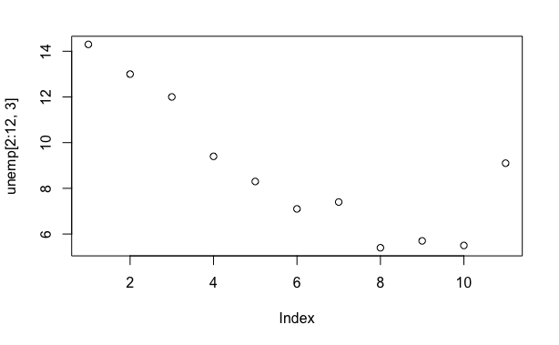

```r
plot(unemp[2:12,3])
```

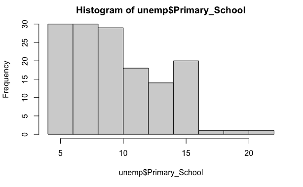

```r
hist(unemp$Primary_School)
```

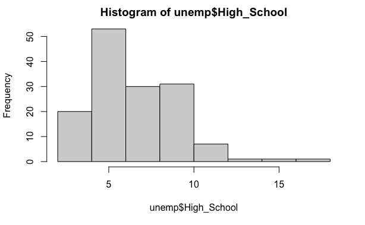

```r
hist(unemp$High_School)
```

Here I imported the data and I have found that the original data set put all the Januaries together, Febuaries together, etc, not the way I wanted. So I regrouped the data, making it in rank of years.

```r
library('ggplot2')
library('forecast')
library('tseries')
```

REGROUP CODE:

```r
unemp10<-unemp[unemp$Year=="2010",]
unemp11<-unemp[unemp$Year=="2011",]
unemp12<-unemp[unemp$Year=="2012",]
unemp13<-unemp[unemp$Year=="2013",]
unemp14<-unemp[unemp$Year=="2014",]
unemp15<-unemp[unemp$Year=="2015",]
unemp16<-unemp[unemp$Year=="2016",]
unemp17<-unemp[unemp$Year=="2017",]
unemp18<-unemp[unemp$Year=="2018",]
unemp19<-unemp[unemp$Year=="2019",]
unemp20<-unemp[unemp$Year=="2020",]
unemp21<-unemp[unemp$Year=="2021",]
unempall.1 <- rbind(unemp10, unemp11)
unempall.2<- rbind(unempall.1, unemp12)
unempall.3<- rbind(unempall.2, unemp13)
unempall.4<- rbind(unempall.3, unemp14)
unempall.5<- rbind(unempall.4, unemp15)
unempall.6<- rbind(unempall.5, unemp16)
unempall.7<- rbind(unempall.6, unemp17)
unempall.8<- rbind(unempall.7, unemp18)
unempall.9<- rbind(unempall.8, unemp19)
unempall.10<- rbind(unempall.9, unemp20)
unempall<- rbind(unempall.10, unemp21)
```

Split the data into train and test （we delete two months from test group due to length match in later accuracy function）

```r
train = unempall.10
test = unemp21[-c(11,12),]

train
```

|  | Year | Month | Primary_School | High_School | Associates_Degree | Professional_Degree | White | Black | Asian | Hispanic | Men | Women | California | Florida | Texas | NY | Cal_case | Flo_case | Tex_case | NY_case | US_case |
| --- | --- | --- | --- | --- | --- | --- | --- | --- | --- | --- | --- | --- | --- | --- | --- | --- | --- | --- | --- | --- | --- |
| 1 | 2010 | Jan | 15.3 | 10.2 | 8.6 | 4.9 | 8.8 | 16.5 | 8.3 | 12.9 | 10.2 | 7.9 | 12.6 | 10.9 | 8.3 | 9.0 | 0 | 0 | 0 | 0 | 0 |
| 13 | 2010 | Feb | 15.8 | 10.7 | 8.1 | 4.9 | 8.9 | 16.1 | 8.2 | 12.7 | 10.3 | 8.0 | 12.6 | 10.9 | 8.3 | 9.0 | 0 | 0 | 0 | 0 | 0 |
| 25 | 2010 | Mar | 14.9 | 11.0 | 8.4 | 4.9 | 8.9 | 16.8 | 7.6 | 12.9 | 10.2 | 8.1 | 12.6 | 10.9 | 8.3 | 8.9 | 0 | 0 | 0 | 0 | 0 |
| 37 | 2010 | Apr | 14.7 | 10.8 | 8.4 | 4.8 | 9.0 | 16.6 | 7.0 | 12.5 | 10.2 | 8.3 | 12.5 | 10.9 | 8.2 | 8.8 | 0 | 0 | 0 | 0 | 0 |
| 49 | 2010 | May | 14.6 | 10.9 | 8.2 | 4.6 | 8.7 | 15.5 | 7.8 | 12.0 | 9.7 | 8.1 | 12.5 | 10.8 | 8.2 | 8.8 | 0 | 0 | 0 | 0 | 0 |
| 61 | 2010 | Jun | 14.2 | 10.6 | 8.1 | 4.4 | 8.6 | 15.2 | 7.4 | 12.3 | 9.7 | 7.7 | 12.4 | 10.8 | 8.1 | 8.7 | 0 | 0 | 0 | 0 | 0 |
| 73 | 2010 | Jul | 13.5 | 10.0 | 8.3 | 4.5 | 8.5 | 15.6 | 7.9 | 12.2 | 9.6 | 7.9 | 12.3 | 10.8 | 8.1 | 8.6 | 0 | 0 | 0 | 0 | 0 |
| 85 | 2010 | Aug | 14.1 | 10.0 | 8.7 | 4.6 | 8.6 | 15.9 | 7.3 | 12.0 | 9.6 | 8.0 | 12.4 | 10.8 | 8.1 | 8.6 | 0 | 0 | 0 | 0 | 0 |
| 97 | 2010 | Sep | 15.6 | 9.7 | 8.9 | 4.5 | 8.6 | 16.0 | 6.6 | 12.3 | 9.6 | 8.0 | 12.4 | 10.8 | 8.1 | 8.6 | 0 | 0 | 0 | 0 | 0 |
| 109 | 2010 | Oct | 15.0 | 9.8 | 8.2 | 4.6 | 8.6 | 15.6 | 7.2 | 12.3 | 9.4 | 8.0 | 12.4 | 10.8 | 8.2 | 8.6 | 0 | 0 | 0 | 0 | 0 |

[output cut: 122 more lines]

```r
test
```

|  | Year | Month | Primary_School | High_School | Associates_Degree | Professional_Degree | White | Black | Asian | Hispanic | Men | Women | California | Florida | Texas | NY | Cal_case | Flo_case | Tex_case | NY_case | US_case |
| --- | --- | --- | --- | --- | --- | --- | --- | --- | --- | --- | --- | --- | --- | --- | --- | --- | --- | --- | --- | --- | --- |
| 12 | 2021 | Jan | 9.1 | 7.1 | 6.2 | 4.0 | 5.7 | 9.2 | 6.6 | 8.6 | 6.0 | 6.0 | 8.8 | 6.0 | 6.7 | 8.6 | 92588471 | 47886722 | 65807240 | 37738018 | 733762462 |
| 24 | 2021 | Feb | 10.1 | 7.2 | 5.9 | 3.8 | 5.6 | 9.9 | 5.1 | 8.5 | 6.0 | 5.9 | 8.6 | 5.6 | 6.6 | 8.4 | 98972712 | 51110285 | 72509527 | 43092026 | 776828495 |
| 36 | 2021 | Mar | 8.2 | 6.7 | 5.9 | 3.7 | 5.4 | 9.6 | 6.0 | 7.9 | 5.8 | 5.7 | 8.4 | 5.4 | 6.4 | 7.9 | 114248991 | 61554303 | 85890518 | 54448749 | 919640537 |
| 48 | 2021 | Apr | 9.3 | 6.9 | 5.8 | 3.5 | 5.3 | 9.7 | 5.7 | 7.9 | 6.1 | 5.6 | 8.3 | 5.1 | 6.2 | 7.8 | 113165874 | 64514411 | 86432863 | 59305995 | 947649319 |
| 60 | 2021 | May | 9.1 | 6.8 | 5.9 | 3.2 | 5.1 | 9.1 | 5.5 | 7.3 | 5.9 | 5.4 | 7.9 | 4.9 | 5.9 | 7.4 | 118803680 | 70924763 | 91943427 | 64552427 | 1023416131 |
| 72 | 2021 | Jun | 10.2 | 7.0 | 5.8 | 3.5 | 5.2 | 9.2 | 5.8 | 7.4 | 5.9 | 5.5 | 7.9 | 4.8 | 5.9 | 7.4 | 116124787 | 70395623 | 90475797 | 63291737 | 1007923759 |
| 84 | 2021 | Jul | 9.5 | 6.3 | 5.0 | 3.1 | 4.8 | 8.2 | 5.3 | 6.6 | 5.4 | 5.0 | 7.4 | 4.5 | 5.6 | 6.9 | 122149679 | 75953211 | 95481236 | 65943806 | 1061500507 |
| 96 | 2021 | Aug | 7.8 | 6.0 | 5.1 | 2.8 | 4.5 | 8.8 | 4.6 | 6.4 | 5.1 | 4.8 | 7.0 | 4.3 | 5.4 | 6.6 | 131774496 | 91121919 | 105282868 | 68551270 | 1151018178 |
| 108 | 2021 | Sep | 7.9 | 5.8 | 4.5 | 2.5 | 4.2 | 7.9 | 4.2 | 6.3 | 4.7 | 4.2 | 6.4 | 3.9 | 5.1 | 6.0 | 138670868 | 104089489 | 117003017 | 70629706 | 1250234524 |
| 120 | 2021 | Oct | 7.4 | 5.4 | 4.4 | 2.4 | 4.0 | 7.9 | 4.2 | 5.9 | 4.3 | 4.4 | 6.1 | 3.7 | 5.0 | 5.7 | 149871455 | 113329514 | 130146709 | 77480492 | 1392847523 |

The first graph is grouped by races

```r
unempall
```

|  | Year | Month | Primary_School | High_School | Associates_Degree | Professional_Degree | White | Black | Asian | Hispanic | Men | Women | California | Florida | Texas | NY | Cal_case | Flo_case | Tex_case | NY_case | US_case |
| --- | --- | --- | --- | --- | --- | --- | --- | --- | --- | --- | --- | --- | --- | --- | --- | --- | --- | --- | --- | --- | --- |
| 1 | 2010 | Jan | 15.3 | 10.2 | 8.6 | 4.9 | 8.8 | 16.5 | 8.3 | 12.9 | 10.2 | 7.9 | 12.6 | 10.9 | 8.3 | 9.0 | 0 | 0 | 0 | 0 | 0 |
| 13 | 2010 | Feb | 15.8 | 10.7 | 8.1 | 4.9 | 8.9 | 16.1 | 8.2 | 12.7 | 10.3 | 8.0 | 12.6 | 10.9 | 8.3 | 9.0 | 0 | 0 | 0 | 0 | 0 |
| 25 | 2010 | Mar | 14.9 | 11.0 | 8.4 | 4.9 | 8.9 | 16.8 | 7.6 | 12.9 | 10.2 | 8.1 | 12.6 | 10.9 | 8.3 | 8.9 | 0 | 0 | 0 | 0 | 0 |
| 37 | 2010 | Apr | 14.7 | 10.8 | 8.4 | 4.8 | 9.0 | 16.6 | 7.0 | 12.5 | 10.2 | 8.3 | 12.5 | 10.9 | 8.2 | 8.8 | 0 | 0 | 0 | 0 | 0 |
| 49 | 2010 | May | 14.6 | 10.9 | 8.2 | 4.6 | 8.7 | 15.5 | 7.8 | 12.0 | 9.7 | 8.1 | 12.5 | 10.8 | 8.2 | 8.8 | 0 | 0 | 0 | 0 | 0 |
| 61 | 2010 | Jun | 14.2 | 10.6 | 8.1 | 4.4 | 8.6 | 15.2 | 7.4 | 12.3 | 9.7 | 7.7 | 12.4 | 10.8 | 8.1 | 8.7 | 0 | 0 | 0 | 0 | 0 |
| 73 | 2010 | Jul | 13.5 | 10.0 | 8.3 | 4.5 | 8.5 | 15.6 | 7.9 | 12.2 | 9.6 | 7.9 | 12.3 | 10.8 | 8.1 | 8.6 | 0 | 0 | 0 | 0 | 0 |
| 85 | 2010 | Aug | 14.1 | 10.0 | 8.7 | 4.6 | 8.6 | 15.9 | 7.3 | 12.0 | 9.6 | 8.0 | 12.4 | 10.8 | 8.1 | 8.6 | 0 | 0 | 0 | 0 | 0 |
| 97 | 2010 | Sep | 15.6 | 9.7 | 8.9 | 4.5 | 8.6 | 16.0 | 6.6 | 12.3 | 9.6 | 8.0 | 12.4 | 10.8 | 8.1 | 8.6 | 0 | 0 | 0 | 0 | 0 |
| 109 | 2010 | Oct | 15.0 | 9.8 | 8.2 | 4.6 | 8.6 | 15.6 | 7.2 | 12.3 | 9.4 | 8.0 | 12.4 | 10.8 | 8.2 | 8.6 | 0 | 0 | 0 | 0 | 0 |

[output cut: 134 more lines]

```r
plot(unempall$White, type='l', xaxt='n',ylim=c(0,28), ylab= "unemployment rate")
legend(75, 28, legend=c("White", "Asian", "Hispanic", "Black"),
       col=c("black", "red", "blue", "pink"), lty=1:2, cex=0.8)
```

```r
axis(1, labels=2010:2022, at=(0:12)*12+1)
points(unempall$Asian,type='l', xaxt='n', col = "red")
```

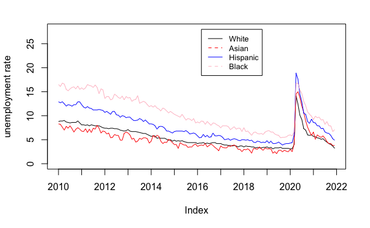

```r
points(unempall$Hispanic,type='l', xaxt='n', col = "blue")
points(unempall$Black,type='l', xaxt='n', col = "pink")
```

The second graph is grouped by academic background

```r
plot(unempall$Primary_School, type='l', xaxt='n',ylim=c(0,28), ylab= "unemployment rate")
legend(55, 28, legend=c("Primary_School", "Highschool", "Associate_Degree", "Professional_Degree"),
       col=c("black", "red", "blue", "pink"), lty=1:2, cex=0.8)
```

```r
axis(1, labels=2010:2022, at=(0:12)*12+1)
points(unempall$High_School,type='l', xaxt='n', col = "red")
```

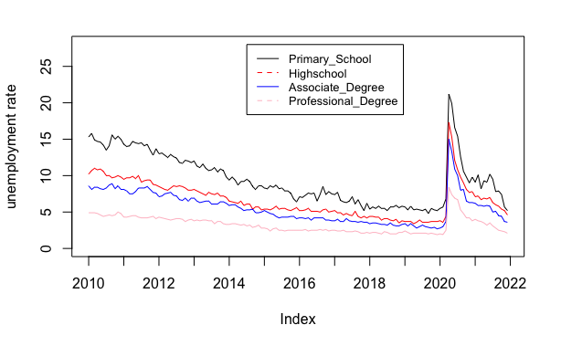

```r
points(unempall$Associates_Degree,type='l', xaxt='n', col = "blue")
points(unempall$Professional_Degree,type='l', xaxt='n', col = "pink")
```

The third graph is grouped by genders

```r
plot(unempall$Men, type='l', xaxt='n',ylim=c(0,20), ylab= "unemployment rate")
legend(80, 20, legend=c("Men", "Women"),
       col=c("black", "red"), lty=1:2, cex=0.8)
```

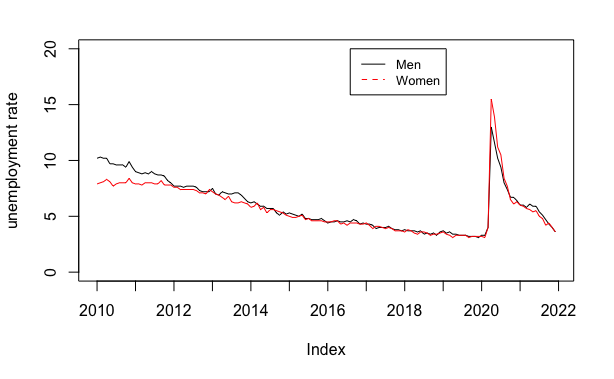

```r
axis(1, labels=2010:2022, at=(0:12)*12+1)
points(unempall$Women,type='l', xaxt='n', col = "red")
```

The fourth graph is grouped by states.

```r
plot(unempall$California, type='l', xaxt='n',ylim=c(0,20), ylab= "unemployment rate")
legend(80, 20, legend=c("California", "Florida", "New_York", "Texas"),
       col=c("black", "red", "blue", "pink"), lty=1:2, cex=0.8)
```

```r
axis(1, labels=2010:2022, at=(0:12)*12+1)
points(unempall$Florida,type='l', xaxt='n', col = "red")
```

[figure not shown]

```r
points(unempall$New_York,type='l', xaxt='n', col = "blue")
points(unempall$Texas,type='l', xaxt='n', col = "pink")
```

This is the arima for Primary school.

```r
tsallp <- ts(data=train$Primary_School)
autoarimatsallp <- auto.arima(tsallp,stepwise = F,approximation = F)
forecasttsallp <- forecast(autoarimatsallp)
forecasttsallp$residuals
```

```
Time Series:
Start = 1
End = 132
Frequency = 1
  [1]  0.01529999  0.48500904 -0.88867858 -0.08987129 -0.18108834 -0.46357691
  [7] -0.76752584  0.46830695  1.27041388 -0.65790547  0.58675551 -0.39171082
 [13] -0.59000903 -0.30321827 -0.01195955  0.47074166 -0.28286053 -0.07140222
 [19]  0.06664485 -0.43421977  0.18547938 -0.88673266 -0.73169305  0.71059095
 [25] -0.95098611  0.05508706 -0.50219432 -0.42785662  0.22026273 -0.49405039
 [31] -0.29235533 -0.75357715 -0.26160708  0.15387534 -0.30810398 -0.31189795
 [37]  0.06722853 -0.84351626 -0.29037770  0.28408293 -0.79220330 -0.38242175
 [43] -0.10222998  0.09628817 -0.75172833  0.31040036 -0.39285565 -0.97418158
 [49] -0.52982023  0.13200641 -0.67155645 -0.86116405  0.26328196 -0.31004984
 [55]  0.14092564 -0.45977340 -0.78392932 -0.54657517  0.25546929 -0.25797063
 [61] -0.42572307 -0.23384405  0.23212247 -0.35080128  0.23964196 -0.60128081
 [67]  0.07116466 -0.52779391 -0.07625243 -0.44704185 -0.91498275 -0.56596216
 [73]  0.41865558 -0.38414106  0.18555264  0.15653064 -0.15908991  0.08808261
 [79] -1.13596155  0.88135103  0.88939338 -1.06942662  0.57171977 -0.37623029
 [85] -0.04968588  0.26410221 -1.13010633 -0.18268100 -0.29620300  0.03474939
 [91]  0.43765368 -1.09624757  0.60573498 -0.99000446 -0.72431393  0.79666042
 [97] -1.05798384  0.26506817 -0.41310198  0.20404307 -0.43639760 -0.05682537
[103] -0.41742411  0.40833177 -0.13237947  0.18597710 -0.33153185  0.20990500
[109] -0.15182626 -0.39734628  0.47023656 -0.58738779  0.12243931 -0.19102659
[115] -0.13945111  0.13789541 -0.66492478  0.67593834 -0.33037283 -0.06588570
[121]  0.26163729  0.16529734  1.12642193 14.45842712 -0.91603175 -0.42293472
[127]  0.52219314 -1.73874023 -1.22345500 -0.61757966 -0.90878850  0.60711391
```

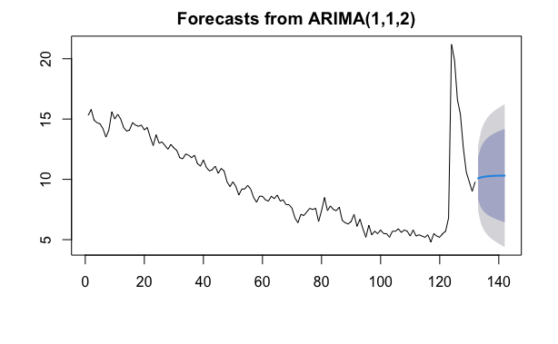

```r
plot(forecasttsallp)
```

```r
summary(autoarimatsallp)
```

```
Series: tsallp
ARIMA(1,1,2)

Coefficients:
         ar1      ma1      ma2
      0.6580  -0.6677  -0.1821
s.e.  0.1515   0.1719   0.1091

sigma^2 = 1.96:  log likelihood = -228.58
AIC=465.17   AICc=465.49   BIC=476.67

Training set error measures:
                      ME     RMSE       MAE       MPE     MAPE      MASE
Training set -0.08342737 1.378691 0.5672485 -1.688901 5.876737 0.9563648
                     ACF1
Training set -0.007588783
```

```r
length(forecasttsallp)
```

```
[1] 10
```

```r
tsallp_test = test$Primary_School
accuracy(forecasttsallp,tsallp_test)
```

```
                      ME     RMSE       MAE        MPE      MAPE      MASE
Training set -0.08342737 1.378691 0.5672485  -1.688901  5.876737 0.9563648
Test set     -1.38889245 1.687428 1.3888924 -17.023610 17.023610 2.3416333
                     ACF1
Training set -0.007588783
Test set               NA
```

This is the arima for High school.

```r
tsallh <- ts(data=train$High_School)
autoarimatsallh <- auto.arima(tsallh)
forecasttsallh <- forecast(autoarimatsallh)
forecasttsallh$residuals
```

```
Time Series:
Start = 1
End = 132
Frequency = 1
  [1]  0.0101999945  0.4807985195  0.2941276215 -0.0996853988  0.2014938365
  [6] -0.2514293522 -0.5459971998 -0.0537979306 -0.4372273444 -0.0128500312
 [11]  0.0531135153 -0.2771213938 -0.3495753716  0.0949208691 -0.1181669114
 [16]  0.1471816208 -0.3411244837  0.3830599896 -0.9492084120  0.1825885352
 [21] -0.0829617805 -0.0677816064 -0.6572654052 -0.1899017902 -0.3904461752
 [26] -0.3664536117 -0.3913355238 -0.3016725078  0.0941828598  0.1372713416
 [31] -0.1589209388  0.0843331418 -0.1336915599 -0.2108071165 -0.3467866959
 [36] -0.0906879505 -0.0229552570 -0.2851716953 -0.2700085176 -0.3123407453
 [41] -0.3349626264  0.2430424562 -0.3327228771 -0.1465200595  0.0995206326
 [46] -0.4755491124 -0.0541268961 -0.3261355779 -0.6009035899 -0.2600596222
 [51] -0.3218149785 -0.2922157460  0.1135547593 -0.7491559124  0.0901233950
```

[output cut: 16 more lines]

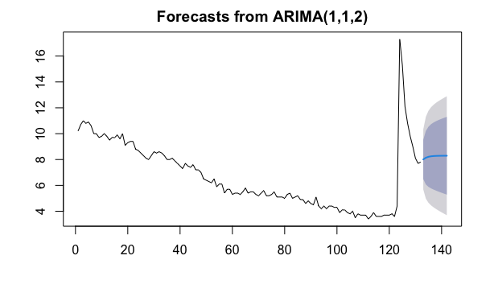

```r
plot(forecasttsallh)
```

```r
summary(autoarimatsallh)
```

```
Series: tsallh
ARIMA(1,1,2)

Coefficients:
         ar1      ma1      ma2
      0.5348  -0.6047  -0.1964
s.e.  0.2073   0.2169   0.1170

sigma^2 = 1.405:  log likelihood = -206.76
AIC=421.53   AICc=421.85   BIC=433.03

Training set error measures:
                      ME     RMSE       MAE       MPE    MAPE      MASE
Training set -0.03546934 1.167049 0.3361282 -1.540128 4.46417 0.9135433
                     ACF1
Training set -0.005980944
```

```r
tsallh_test = test$High_School
tsallh_test
```

```
 [1] 7.1 7.2 6.7 6.9 6.8 7.0 6.3 6.0 5.8 5.4
```

```r
accuracy(forecasttsallh,tsallh_test)
```

```
                      ME     RMSE       MAE        MPE     MAPE      MASE
Training set -0.03546934 1.167049 0.3361282  -1.540128  4.46417 0.9135433
Test set     -1.71263618 1.827531 1.7126362 -27.418864 27.41886 4.6546751
                     ACF1
Training set -0.005980944
Test set               NA
```

This is the arima for Associate degree.

```r
tsallASS <- ts(data=train$Associates_Degree)
autoarimatsallASS <- auto.arima(tsallASS)
forecasttsallASS <- forecast(autoarimatsallASS)
forecasttsallASS$residuals
```

```
Time Series:
Start = 1
End = 132
Frequency = 1
  [1]  0.008599995 -0.486472609  0.242733791 -0.011417863 -0.207258497
  [6] -0.132862118  0.154463899  0.384179357  0.242043057 -0.628774707
 [11]  0.360045535 -0.475272794 -0.051770253 -0.246702728 -0.471713191
 [16] -0.125705210  0.184476121  0.438843078  0.019627578  0.017987167
 [21]  0.216324790 -0.354376188 -0.418727360 -0.177984753 -0.586570879
 [26] -0.055635242  0.172308225  0.028499375  0.049592387 -0.430952623
 [31] -0.189426445 -0.597301705 -0.265636181  0.132621381 -0.507867440
 [36]  0.239857806 -0.085983832 -0.478940572 -0.333563461 -0.053198573
 [41] -0.025418790 -0.099905547 -0.491740373 -0.145340126 -0.133474465
 [46]  0.177418435 -0.066755006 -0.261304174 -0.386845310 -0.025578505
 [51] -0.100054509 -0.391886663 -0.330208374 -0.450128281 -0.083697934
```

[output cut: 16 more lines]

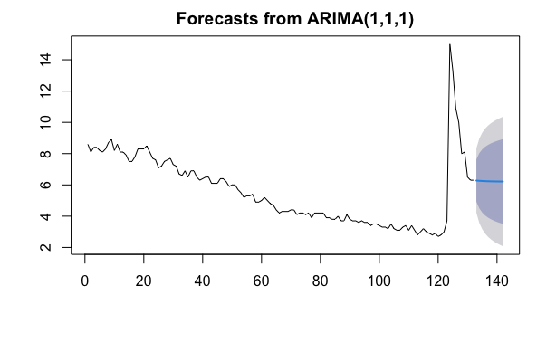

```r
plot(forecasttsallASS)
```

```r
summary(autoarimatsallASS)
```

```
Series: tsallASS
ARIMA(1,1,1)

Coefficients:
         ar1      ma1
      0.7656  -0.9184
s.e.  0.0995   0.0604

sigma^2 = 1.106:  log likelihood = -191.64
AIC=389.28   AICc=389.47   BIC=397.91

Training set error measures:
                      ME     RMSE       MAE       MPE     MAPE      MASE
Training set -0.04973279 1.039769 0.3149057 -2.094773 4.962677 0.9661041
                   ACF1
Training set 0.06471564
```

```r
tsallass_test = test$Associates_Degree
tsallass_test
```

```
 [1] 6.2 5.9 5.9 5.8 5.9 5.8 5.0 5.1 4.5 4.4
```

```r
accuracy(forecasttsallASS,tsallass_test)
```

```
                      ME      RMSE       MAE        MPE      MAPE      MASE
Training set -0.04973279 1.0397688 0.3149057  -2.094773  4.962677 0.9661041
Test set     -0.78709749 0.9873691 0.7870975 -15.985719 15.985719 2.4147487
                   ACF1
Training set 0.06471564
Test set             NA
```

This is the arima for Professional Degree.

```r
tsallPro <- ts(data=train$Professional_Degree)
autoarimatsallPro <- auto.arima(tsallPro)
forecasttsallPro <- forecast(autoarimatsallPro)
forecasttsallPro$residuals
```

```
Time Series:
Start = 1
End = 132
Frequency = 1
  [1]  0.004899998  0.000000000  0.000000000 -0.100000000 -0.200000000
  [6] -0.200000000  0.100000000  0.100000000 -0.100000000  0.100000000
 [11]  0.400000000 -0.200000000 -0.500000000  0.000000000  0.100000000
 [16]  0.100000000  0.000000000 -0.200000000 -0.100000000  0.000000000
 [21]  0.000000000  0.100000000  0.100000000 -0.300000000  0.200000000
 [26] -0.100000000 -0.100000000 -0.100000000 -0.100000000  0.100000000
 [31]  0.100000000  0.000000000 -0.100000000 -0.300000000  0.200000000
 [36]  0.100000000 -0.200000000  0.100000000 -0.100000000  0.100000000
 [41]  0.000000000 -0.100000000  0.000000000 -0.400000000  0.300000000
 [46]  0.000000000 -0.300000000 -0.100000000  0.000000000  0.100000000
 [51]  0.000000000 -0.100000000 -0.100000000  0.100000000 -0.200000000
```

[output cut: 16 more lines]

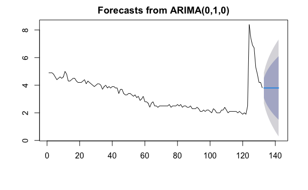

```r
plot(forecasttsallPro)
```

```r
summary(autoarimatsallPro)
```

```
Series: tsallPro
ARIMA(0,1,0)

sigma^2 = 0.3207:  log likelihood = -111.39
AIC=224.78   AICc=224.81   BIC=227.65

Training set error measures:
                       ME      RMSE       MAE       MPE     MAPE      MASE
Training set -0.008296212 0.5641434 0.1871583 -0.768616 4.823253 0.9926211
                    ACF1
Training set -0.02609171
```

```r
tsallpro_test = test$Professional_Degree
tsallpro_test
```

```
 [1] 4.0 3.8 3.7 3.5 3.2 3.5 3.1 2.8 2.5 2.4
```

```r
accuracy(forecasttsallPro,tsallpro_test)
```

```
                       ME      RMSE       MAE        MPE      MAPE      MASE
Training set -0.008296212 0.5641434 0.1871583  -0.768616  4.823253 0.9926211
Test set     -0.550000000 0.7569676 0.5900000 -20.222382 21.222382 3.1291498
                    ACF1
Training set -0.02609171
Test set              NA
```

This is the arima for White people.

```r
tsallw <- ts(data=train$White)
autoarimatsallw <- auto.arima(tsallw)
forecasttsallw <- forecast(autoarimatsallw)
forecasttsallw$residuals
```

```
Time Series:
Start = 1
End = 132
Frequency = 1
  [1]  0.0087999953  0.0964659393  0.0006917419  0.1117162825 -0.2803747934
  [6] -0.0840671558 -0.1328270732  0.0515677376 -0.0490653997 -0.0280555512
 [11]  0.2750877387 -0.4009073867 -0.3847304864 -0.0694433224 -0.2156943608
 [16] -0.0065632737 -0.2990652473  0.1148979193 -0.1878447200 -0.1546142867
 [21] -0.0679356749 -0.0726477311 -0.2627111774 -0.2677477463 -0.2000974303
 [26] -0.1212340697 -0.2186844533 -0.0093047402 -0.1015774149 -0.1737263794
 [31] -0.0704811743 -0.1748611624 -0.2714612509 -0.1893318597 -0.2119477092
 [36] -0.0174854529  0.0913559353 -0.3662076006 -0.1496256300 -0.0916519506
 [41] -0.0931459421 -0.1804419909 -0.1762829034 -0.1866852572 -0.1956688835
 [46] -0.1034272846 -0.3033153307 -0.3028488938 -0.3304344319 -0.0542576855
 [51] -0.1543951313 -0.6193435101 -0.0371277121 -0.2815839862 -0.1496363927
```

[output cut: 16 more lines]

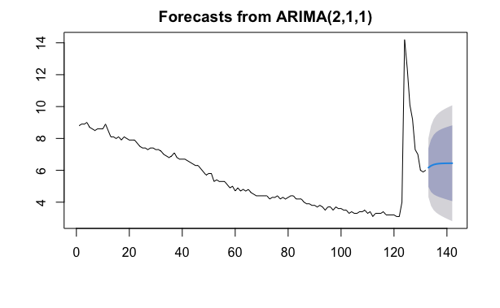

```r
plot(forecasttsallw)
```

```r
summary(autoarimatsallw)
```

```
Series: tsallw
ARIMA(2,1,1)

Coefficients:
         ar1      ar2      ma1
      0.7955  -0.1399  -0.8636
s.e.  0.1130   0.0918   0.0796

sigma^2 = 0.8812:  log likelihood = -176.24
AIC=360.48   AICc=360.8   BIC=371.98

Training set error measures:
                      ME      RMSE       MAE       MPE     MAPE     MASE
Training set -0.04476048 0.9243689 0.2498635 -1.653324 3.763462 1.004053
                     ACF1
Training set -0.004414551
```

```r
tsallw_test = test$White
tsallw_test
```

```
 [1] 5.7 5.6 5.4 5.3 5.1 5.2 4.8 4.5 4.2 4.0
```

```r
accuracy(forecasttsallw,tsallw_test)
```

```
                      ME      RMSE       MAE        MPE      MAPE     MASE
Training set -0.04476048 0.9243689 0.2498635  -1.653324  3.763462 1.004053
Test set     -1.40256659 1.5337101 1.4025666 -30.021107 30.021107 5.636080
                     ACF1
Training set -0.004414551
Test set               NA
```

This is the arima for Asian.

```r
tsallA <- ts(data=train$Asian)
autoarimatsallA <- auto.arima(tsallA)
forecasttsallA <- forecast(autoarimatsallA)
forecasttsallA$residuals
```

```
Time Series:
Start = 1
End = 132
Frequency = 1
  [1]  0.008299996 -0.100000000 -0.600000000 -0.600000000  0.800000000
  [6] -0.400000000  0.500000000 -0.600000000 -0.700000000  0.600000000
 [11]  0.300000000 -0.300000000 -0.400000000 -0.100000000  0.600000000
 [16] -0.800000000  0.700000000 -0.700000000  0.900000000 -0.200000000
 [21]  0.800000000 -0.600000000 -1.000000000  0.400000000 -0.100000000
 [26] -0.500000000  0.200000000 -1.000000000  0.100000000  0.600000000
 [31] -0.200000000  0.000000000 -1.000000000  0.000000000  1.400000000
 [36]  0.300000000 -0.200000000 -0.400000000 -0.900000000  0.200000000
 [41] -0.800000000  0.200000000  0.600000000 -0.200000000  0.300000000
 [46]  0.000000000 -0.200000000 -0.900000000  0.400000000  1.200000000
 [51] -0.400000000  0.400000000 -0.200000000 -1.000000000 -0.500000000
```

[output cut: 16 more lines]

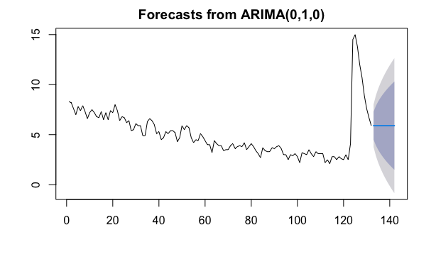

```r
plot(forecasttsallA)
```

```r
summary(autoarimatsallA)
```

```
Series: tsallA
ARIMA(0,1,0)

sigma^2 = 1.185:  log likelihood = -197.01
AIC=396.02   AICc=396.05   BIC=398.89

Training set error measures:
                      ME     RMSE       MAE       MPE     MAPE      MASE
Training set -0.01811894 1.084533 0.5394568 -1.476056 10.31301 0.9925399
                  ACF1
Training set 0.1506271
```

```r
tsalla_test = test$Asian
tsalla_test
```

```
 [1] 6.6 5.1 6.0 5.7 5.5 5.8 5.3 4.6 4.2 4.2
```

```r
accuracy(forecasttsallA,tsalla_test)
```

```
                      ME      RMSE       MAE        MPE     MAPE      MASE
Training set -0.01811894 1.0845334 0.5394568  -1.476056 10.31301 0.9925399
Test set     -0.60000000 0.9581232 0.7600000 -13.645319 16.09986 1.3983146
                  ACF1
Training set 0.1506271
Test set            NA
```

This is arima for Black people.

```r
tsallB <- ts(data=train$Black)
autoarimatsallB <- auto.arima(tsallB)
forecasttsallB <- forecast(autoarimatsallB)
forecasttsallB$residuals
```

```
Time Series:
Start = 1
End = 132
Frequency = 1
  [1]  0.01649999 -0.40000000  0.70000000 -0.20000000 -1.10000000 -0.30000000
  [7]  0.40000000  0.30000000  0.10000000 -0.40000000  0.60000000 -0.70000000
 [13]  0.30000000 -0.30000000  0.30000000  0.70000000 -0.20000000 -0.10000000
 [19] -0.30000000  0.50000000 -0.50000000 -1.30000000  1.00000000 -0.20000000
 [25] -1.80000000  0.40000000  0.00000000 -0.70000000  0.20000000  1.00000000
 [31] -0.30000000 -0.40000000 -0.20000000  0.50000000 -0.80000000  0.70000000
 [37] -0.30000000  0.10000000 -0.80000000  0.30000000  0.10000000  0.80000000
 [43] -1.60000000  0.20000000  0.20000000 -0.20000000 -0.50000000 -0.40000000
 [49]  0.20000000 -0.30000000  0.30000000 -0.50000000 -0.20000000 -0.40000000
 [55]  0.60000000 -0.20000000 -0.40000000 -0.40000000  0.30000000 -0.30000000
 [61] -0.30000000 -0.20000000 -0.20000000 -0.20000000  0.60000000 -0.60000000
 [67] -0.60000000  0.30000000 -0.10000000 -0.30000000  0.40000000 -0.90000000
 [73]  0.20000000 -0.20000000  0.40000000 -0.10000000 -0.60000000  0.60000000
 [79] -0.40000000 -0.40000000  0.50000000 -0.10000000 -0.30000000 -0.20000000
 [85] -0.40000000  0.40000000  0.00000000  0.00000000 -0.20000000 -0.60000000
 [91]  0.30000000  0.30000000 -0.50000000  0.20000000  0.00000000 -0.70000000
 [97]  0.80000000 -0.80000000  0.10000000 -0.40000000 -0.50000000  0.60000000
[103]  0.10000000 -0.30000000 -0.10000000  0.10000000 -0.20000000  0.50000000
[109]  0.20000000  0.10000000 -0.30000000  0.00000000 -0.40000000 -0.20000000
[115] -0.10000000 -0.50000000  0.10000000  0.00000000  0.10000000  0.30000000
[121]  0.10000000 -0.20000000  0.90000000 10.00000000  0.10000000 -1.40000000
[127] -0.80000000 -1.60000000 -0.90000000 -1.30000000 -0.50000000 -0.40000000
```

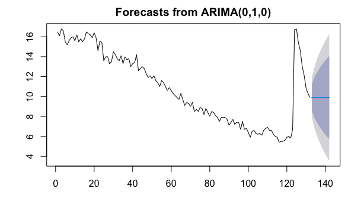

```r
plot(forecasttsallB)
```

```r
summary(autoarimatsallB)
```

```
Series: tsallB
ARIMA(0,1,0)

sigma^2 = 1.054:  log likelihood = -189.32
AIC=380.64   AICc=380.67   BIC=383.51

Training set error measures:
                    ME     RMSE       MAE        MPE     MAPE      MASE
Training set -0.049875 1.022698 0.4910341 -0.7493088 4.446688 0.9926769
                   ACF1
Training set 0.04669715
```

```r
tsallb_test = test$Black
tsallb_test
```

```
 [1] 9.2 9.9 9.6 9.7 9.1 9.2 8.2 8.8 7.9 7.9
```

```r
accuracy(forecasttsallB,tsallb_test)
```

```
                    ME     RMSE       MAE         MPE      MAPE      MASE
Training set -0.049875 1.022698 0.4910341  -0.7493088  4.446688 0.9926769
Test set     -0.950000 1.176860 0.9500000 -11.3060074 11.306007 1.9205247
                   ACF1
Training set 0.04669715
Test set             NA
```

This is arima for Hispanic.

```r
tsallH <- ts(data=train$Hispanic)
autoarimatsallH <- auto.arima(tsallH)
forecasttsallH <- forecast(autoarimatsallH)
forecasttsallH$residuals
```

```
Time Series:
Start = 1
End = 132
Frequency = 1
  [1]  0.012899993 -0.192577734  0.208231841 -0.448186148 -0.444092695
  [6]  0.251439705 -0.250632451 -0.217351108  0.238601876 -0.103176308
 [11]  0.598431462 -0.055627911 -0.484421727 -0.418318784 -0.248174429
 [16]  0.179075115 -0.444335356 -0.124469475 -0.418452732 -0.084339960
 [21] -0.151200523 -0.007402884 -0.203429896 -0.156407875 -0.477645740
 [26]  0.135805782 -0.463625752 -0.346329360  0.473515420 -0.185823129
 [31] -0.690098490 -0.107171414 -0.569104308  0.195465896 -0.313939613
 [36] -0.369898253 -0.003192538 -0.154805641 -0.489535851 -0.370630634
 [41] -0.146789725 -0.075289056  0.158720429 -0.313583224 -0.416707887
 [46]  0.232080329 -0.555476227 -0.413304472 -0.125447029 -0.273546187
 [51] -0.425649778 -0.825223540  0.356385748 -0.208704181 -0.194042645
```

[output cut: 16 more lines]

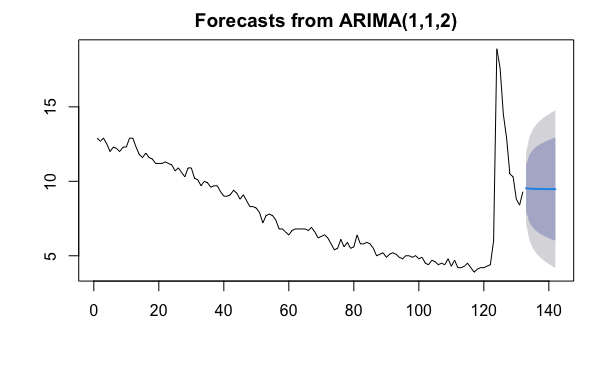

```r
plot(forecasttsallH)
```

```r
summary(autoarimatsallH)
```

```
Series: tsallH
ARIMA(1,1,2)

Coefficients:
         ar1      ma1      ma2
      0.6202  -0.5733  -0.2459
s.e.  0.1583   0.1711   0.1002

sigma^2 = 1.466:  log likelihood = -209.55
AIC=427.1   AICc=427.42   BIC=438.61

Training set error measures:
                      ME     RMSE       MAE       MPE     MAPE      MASE
Training set -0.05316162 1.192248 0.3961838 -1.421441 4.613484 0.9540455
                     ACF1
Training set -0.003340064
```

```r
tsallh_test = test$Hispanic
tsallh_test
```

```
 [1] 8.6 8.5 7.9 7.9 7.3 7.4 6.6 6.4 6.3 5.9
```

```r
accuracy(forecasttsallH,tsallh_test)
```

```
                      ME     RMSE       MAE        MPE      MAPE      MASE
Training set -0.05316162 1.192248 0.3961838  -1.421441  4.613484 0.9540455
Test set     -2.20994050 2.381208 2.2099405 -32.380039 32.380039 5.3217317
                     ACF1
Training set -0.003340064
Test set               NA
```

This is arima for Men.

```r
tsallM <- ts(data=train$Men)
autoarimatsallM <- auto.arima(tsallM)
forecasttsallM <- forecast(autoarimatsallM)
forecasttsallM$residuals
```

```
Time Series:
Start = 1
End = 132
Frequency = 1
  [1]  0.01019999  0.10000000 -0.10000000  0.00000000 -0.50000000  0.00000000
  [7] -0.10000000  0.00000000  0.00000000 -0.20000000  0.50000000 -0.50000000
 [13] -0.40000000 -0.10000000 -0.10000000  0.10000000 -0.10000000  0.20000000
 [19] -0.20000000 -0.10000000  0.00000000 -0.10000000 -0.40000000 -0.20000000
 [25] -0.30000000  0.00000000  0.00000000 -0.10000000  0.10000000  0.00000000
 [31]  0.00000000 -0.10000000 -0.30000000 -0.10000000  0.00000000  0.00000000
 [37]  0.30000000 -0.50000000 -0.10000000  0.30000000 -0.10000000 -0.10000000
 [43]  0.00000000  0.10000000  0.00000000 -0.20000000 -0.30000000 -0.30000000
 [49] -0.10000000  0.10000000 -0.20000000 -0.20000000  0.00000000 -0.20000000
 [55]  0.00000000  0.00000000 -0.40000000 -0.20000000  0.30000000 -0.20000000
 [61]  0.10000000 -0.10000000 -0.10000000 -0.10000000  0.20000000 -0.40000000
 [67]  0.00000000 -0.10000000  0.00000000  0.00000000  0.10000000 -0.20000000
 [73] -0.20000000  0.10000000  0.00000000  0.10000000 -0.10000000  0.00000000
 [79]  0.10000000 -0.10000000  0.20000000 -0.10000000 -0.30000000  0.10000000
 [85] -0.10000000  0.00000000 -0.10000000 -0.30000000  0.10000000  0.00000000
 [91]  0.00000000  0.10000000 -0.20000000 -0.10000000  0.00000000 -0.10000000
 [97]  0.10000000 -0.10000000  0.00000000  0.00000000 -0.10000000  0.10000000
[103] -0.30000000  0.10000000 -0.10000000  0.10000000 -0.20000000  0.30000000
[109]  0.10000000 -0.20000000  0.10000000 -0.20000000  0.00000000 -0.10000000
[115]  0.00000000  0.00000000 -0.10000000  0.00000000  0.00000000 -0.10000000
[121]  0.20000000  0.00000000  0.70000000  9.00000000 -1.40000000 -1.40000000
[127] -0.80000000 -1.40000000 -0.60000000 -0.70000000  0.00000000 -0.30000000
```

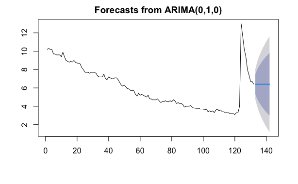

```r
plot(forecasttsallM)
```

```r
summary(autoarimatsallM)
```

```
Series: tsallM
ARIMA(0,1,0)

sigma^2 = 0.7087:  log likelihood = -163.33
AIC=328.66   AICc=328.69   BIC=331.53

Training set error measures:
                      ME      RMSE       MAE        MPE     MAPE      MASE
Training set -0.02871061 0.8386502 0.2425015 -0.8123418 3.403115 0.9927406
                    ACF1
Training set -0.01402214
```

```r
tsallm_test = test$Men
tsallm_test
```

```
 [1] 6.0 6.0 5.8 6.1 5.9 5.9 5.4 5.1 4.7 4.3
```

```r
accuracy(forecasttsallM,tsallm_test)
```

```
                      ME      RMSE       MAE         MPE      MAPE      MASE
Training set -0.02871061 0.8386502 0.2425015  -0.8123418  3.403115 0.9927406
Test set     -0.88000000 1.0611315 0.8800000 -17.4561483 17.456148 3.6025000
                    ACF1
Training set -0.01402214
Test set              NA
```

This is arima for Women.

```r
tsallwo <- ts(data=train$Women)
autoarimatsallwo <- auto.arima(tsallwo)
forecasttsallwo <- forecast(autoarimatsallwo)
forecasttsallwo$residuals
```

```
Time Series:
Start = 1
End = 132
Frequency = 1
  [1]  0.007899996  0.100000000  0.100000000  0.200000000 -0.200000000
  [6] -0.400000000  0.200000000  0.100000000  0.000000000  0.000000000
 [11]  0.400000000 -0.400000000 -0.100000000  0.000000000 -0.100000000
 [16]  0.200000000  0.000000000  0.000000000 -0.100000000  0.000000000
 [21]  0.300000000 -0.400000000  0.000000000  0.000000000 -0.200000000
 [26]  0.000000000 -0.200000000  0.000000000  0.000000000  0.000000000
 [31]  0.000000000 -0.100000000 -0.200000000  0.000000000 -0.100000000
 [36]  0.400000000 -0.200000000 -0.200000000 -0.100000000 -0.200000000
 [41] -0.200000000  0.300000000 -0.500000000 -0.100000000  0.000000000
 [46]  0.100000000 -0.100000000 -0.100000000 -0.300000000  0.100000000
 [51]  0.300000000 -0.600000000  0.200000000 -0.500000000  0.300000000
```

[output cut: 16 more lines]

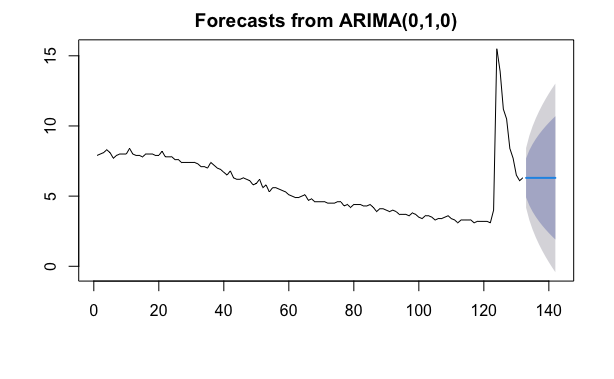

```r
plot(forecasttsallwo)
```

```r
summary(autoarimatsallwo)
```

```
Series: tsallwo
ARIMA(0,1,0)

sigma^2 = 1.175:  log likelihood = -196.42
AIC=394.85   AICc=394.88   BIC=397.72

Training set error measures:
                      ME     RMSE       MAE        MPE     MAPE      MASE
Training set -0.01206136 1.079703 0.2849083 -0.7718967 3.795766 0.9926328
                    ACF1
Training set 0.007467358
```

```r
tsallwo_test = test$Women
tsallwo_test
```

```
 [1] 6.0 5.9 5.7 5.6 5.4 5.5 5.0 4.8 4.2 4.4
```

```r
accuracy(forecasttsallwo,tsallwo_test)
```

```
                      ME     RMSE       MAE         MPE      MAPE      MASE
Training set -0.01206136 1.079703 0.2849083  -0.7718967  3.795766 0.9926328
Test set     -1.05000000 1.204575 1.0500000 -21.6449916 21.644992 3.6582447
                    ACF1
Training set 0.007467358
Test set              NA
```

This is arima for CA.

```r
tsallCA <- ts(data=train$California)
autoarimatsallCA <- auto.arima(tsallCA)
forecasttsallCA <- forecast(autoarimatsallCA)
forecasttsallCA$residuals
```

```
Time Series:
Start = 1
End = 132
Frequency = 1
  [1]  1.259999e-02 -2.516880e-06  2.485336e-06 -9.917837e-02  2.189562e-02
  [6] -1.192040e-01 -8.112488e-02  9.338254e-02 -4.901057e-02  4.750491e-03
 [11] -1.275786e-02 -4.791341e-03 -1.062306e-01 -8.383599e-02 -1.041475e-01
 [16] -1.072427e-01 -1.506319e-02 -4.049520e-02 -2.455704e-02 -1.245654e-01
 [21] -9.904079e-02 -2.173552e-01 -9.787943e-02 -2.454290e-01 -1.113323e-01
 [26] -2.607137e-01 -2.300514e-02 -1.917823e-01 -1.316308e-01 -1.541422e-01
 [31] -2.466475e-01 -2.293030e-01 -1.493253e-01 -2.744260e-01 -1.414784e-01
 [36] -1.844944e-01 -1.646151e-01 -2.681155e-01 -1.430943e-01 -1.833415e-01
 [41] -1.645470e-01 -1.677262e-01 -1.634888e-01 -1.623862e-01 -1.605360e-01
 [46] -2.592857e-01 -1.374929e-01 -1.778614e-01 -2.601230e-01 -1.432522e-01
 [51] -1.809523e-01 -2.634208e-01 -1.458281e-01 -1.832370e-01 -1.653394e-01
```

[output cut: 16 more lines]

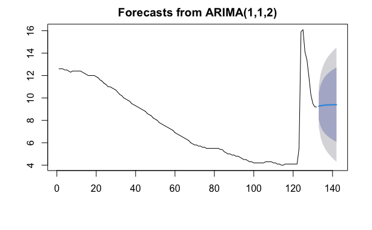

```r
plot(forecasttsallCA)
```

```r
summary(autoarimatsallCA)
```

```
Series: tsallCA
ARIMA(1,1,2)

Coefficients:
         ar1      ma1      ma2
      0.6979  -0.4918  -0.3087
s.e.  0.1642   0.1711   0.0856

sigma^2 = 0.8659:  log likelihood = -175.04
AIC=358.08   AICc=358.4   BIC=369.58

Training set error measures:
                      ME      RMSE       MAE        MPE     MAPE     MASE
Training set -0.03641678 0.9163465 0.2221506 -0.8901906 2.370118 1.039347
                    ACF1
Training set -0.00393757
```

```r
tsallCA_test = test$California
tsallCA_test
```

```
 [1] 8.8 8.6 8.4 8.3 7.9 7.9 7.4 7.0 6.4 6.1
```

```r
accuracy(forecasttsallCA,tsallCA_test)
```

```
                      ME      RMSE       MAE         MPE      MAPE     MASE
Training set -0.03641678 0.9163465 0.2221506  -0.8901906  2.370118 1.039347
Test set     -1.67767243 1.9121892 1.6776724 -23.6491901 23.649190 7.849110
                    ACF1
Training set -0.00393757
Test set              NA
```

This is arima for Florida.

```r
tsallF <- ts(data=train$Florida)
autoarimatsallF <- auto.arima(tsallF)
forecasttsallF <- forecast(autoarimatsallF)
forecasttsallF$residuals
```

```
Time Series:
Start = 1
End = 132
Frequency = 1
  [1]  1.089999e-02 -2.202893e-06  1.824752e-06 -1.556905e-06 -9.493587e-02
  [6]  2.390935e-02 -2.144854e-02  1.943699e-02 -1.776104e-02  1.634241e-02
 [11] -1.512544e-02 -8.367203e-02 -8.142473e-02 -8.351809e-02 -8.154353e-02
 [16] -8.339703e-02 -8.163978e-02 -8.329918e-02 -8.171947e-02 -8.321833e-02
 [21] -1.806874e-01 -5.097641e-02 -2.116666e-01 -2.111966e-02 -1.413307e-01
 [26] -2.597391e-02 -1.367869e-01 -3.023118e-02 -3.343405e-02 -6.716934e-02
 [31] -1.966613e-01 -3.489222e-02 -1.284244e-01 -3.807554e-02 -1.253990e-01
 [36] -4.095197e-02 -1.226577e-01  5.605119e-02 -1.539317e-01 -1.322509e-02
 [41] -2.492779e-01  1.162252e-01 -2.124592e-01  4.366923e-02 -2.049166e-01
 [46]  3.641966e-02 -1.979421e-01  2.970622e-02 -1.914744e-01  2.347232e-02
 [51] -1.854612e-01  1.174894e-01 -2.140884e-01  4.555193e-02 -2.070162e-01
```

[output cut: 16 more lines]

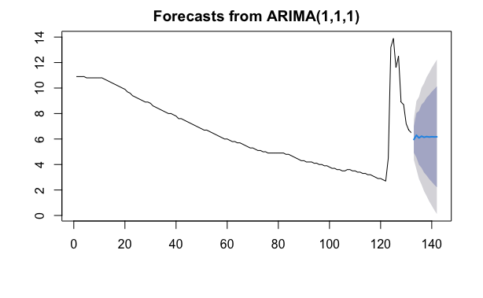

```r
plot(forecasttsallF)
```

```r
summary(autoarimatsallF)
```

```
Series: tsallF
ARIMA(1,1,1)

Coefficients:
          ar1     ma1
      -0.6295  0.9759
s.e.   0.0771  0.0248

sigma^2 = 0.6599:  log likelihood = -158.47
AIC=322.95   AICc=323.13   BIC=331.57

Training set error measures:
                     ME      RMSE       MAE       MPE     MAPE      MASE
Training set -0.0294637 0.8030826 0.2106671 -0.692828 2.891637 0.9582426
                    ACF1
Training set -0.01230463
```

```r
tsallFL_test = test$Florida
tsallFL_test
```

```
 [1] 6.0 5.6 5.4 5.1 4.9 4.8 4.5 4.3 3.9 3.7
```

```r
accuracy(forecasttsallF,tsallFL_test)
```

```
                     ME      RMSE       MAE        MPE      MAPE      MASE
Training set -0.0294637 0.8030826 0.2106671  -0.692828  2.891637 0.9582426
Test set     -1.3373583 1.5234156 1.3449124 -30.625366 30.751267 6.1174835
                    ACF1
Training set -0.01230463
Test set              NA
```

This is arima for Texas.

```r
tsallT <- ts(data=train$Texas)
autoarimatsallT <- auto.arima(tsallT)
forecasttsallT <- forecast(autoarimatsallT)
forecasttsallT$residuals
```

```
Time Series:
Start = 1
End = 132
Frequency = 1
  [1]  8.299995e-03 -1.408429e-06  1.665172e-06 -9.866905e-02  1.809839e-02
  [6] -1.189410e-01  1.227879e-02 -2.898366e-02 -1.163390e-02  8.486109e-02
 [11] -2.773177e-02  1.073832e-02 -2.616830e-03  1.836129e-03 -9.972755e-02
 [16]  1.666259e-02  7.879596e-02  7.771060e-02 -4.079085e-03 -7.871369e-02
 [21] -1.738937e-01 -1.779545e-01 -3.088647e-01 -2.107921e-01 -2.672425e-01
 [26] -1.679067e-01 -4.011861e-01  4.270728e-02 -1.677116e-01 -7.700654e-02
 [31] -1.919130e-01 -1.566420e-01 -1.724284e-01 -7.024335e-02 -8.971537e-02
 [36] -6.930188e-02 -6.423807e-02  4.463949e-02 -1.649484e-01 -5.463329e-03
 [41] -1.527309e-01 -1.404135e-02 -1.536407e-01 -1.711909e-02 -1.555654e-01
 [46] -1.190801e-01 -1.413219e-01 -2.422293e-01 -1.335554e-01 -1.752480e-01
 [51] -1.647869e-01 -1.717671e-01 -1.723505e-01 -1.747708e-01 -7.624436e-02
```

[output cut: 16 more lines]

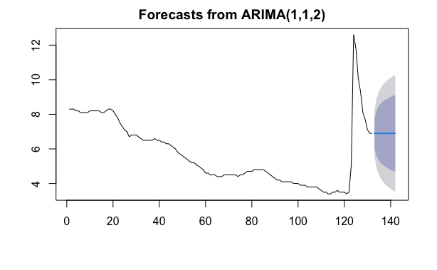

```r
plot(forecasttsallT)
```

```r
summary(autoarimatsallT)
```

```
Series: tsallT
ARIMA(1,1,2)

Coefficients:
         ar1      ma1      ma2
      0.6948  -0.5361  -0.3019
s.e.  0.1574   0.1653   0.0889

sigma^2 = 0.4688:  log likelihood = -134.88
AIC=277.77   AICc=278.09   BIC=289.27

Training set error measures:
                      ME      RMSE       MAE        MPE     MAPE     MASE
Training set -0.01966365 0.6742446 0.1740213 -0.8153845 2.532865 1.026883
                      ACF1
Training set -0.0002479056
```

```r
tsallTX_test = test$Texas
tsallTX_test
```

```
 [1] 6.7 6.6 6.4 6.2 5.9 5.9 5.6 5.4 5.1 5.0
```

```r
accuracy(forecasttsallT,tsallTX_test)
```

```
                      ME      RMSE       MAE         MPE      MAPE     MASE
Training set -0.01966365 0.6742446 0.1740213  -0.8153845  2.532865 1.026883
Test set     -1.01941962 1.1681619 1.0194196 -18.4715114 18.471511 6.015494
                      ACF1
Training set -0.0002479056
Test set                NA
```

This is arima for New York.

```r
tsallNY <- ts(data=train$NY)
autoarimatsallNY <- auto.arima(tsallNY)
forecasttsallNY <- forecast(autoarimatsallNY)
forecasttsallNY$residuals
```

```
Time Series:
Start = 1
End = 132
Frequency = 1
  [1]  0.008999996  0.000000000 -0.100000000 -0.100000000  0.000000000
  [6] -0.100000000 -0.100000000  0.000000000  0.000000000  0.000000000
 [11] -0.100000000  0.000000000 -0.100000000 -0.100000000 -0.100000000
 [16]  0.000000000  0.000000000  0.100000000  0.000000000  0.100000000
 [21]  0.000000000  0.100000000  0.000000000  0.100000000  0.000000000
 [26]  0.000000000  0.100000000  0.100000000  0.000000000  0.000000000
 [31] -0.100000000 -0.100000000  0.000000000 -0.100000000 -0.100000000
 [36]  0.000000000 -0.100000000 -0.100000000 -0.100000000 -0.100000000
 [41] -0.100000000  0.000000000 -0.100000000  0.000000000 -0.200000000
 [46] -0.100000000 -0.200000000 -0.200000000 -0.100000000 -0.200000000
 [51] -0.100000000 -0.200000000 -0.100000000 -0.100000000 -0.100000000
```

[output cut: 16 more lines]

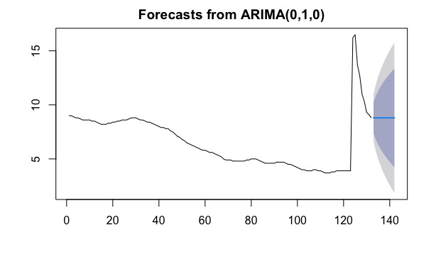

```r
plot(forecasttsallNY)
```

```r
summary(autoarimatsallwo)
```

[output not shown]

```r
tsallNY_test = test$NY
tsallNY_test
```

```
 [1] 8.6 8.4 7.9 7.8 7.4 7.4 6.9 6.6 6.0 5.7
```

```r
accuracy(forecasttsallNY,tsallNY_test)
```

```
                      ME     RMSE       MAE         MPE      MAPE      MASE
Training set -0.00144697 1.120065 0.2106742  -0.5605174  2.056405 0.9927455
Test set     -1.53000000 1.784096 1.5300000 -23.1060439 23.106044 7.2097122
                   ACF1
Training set 0.06050818
Test set             NA
```